# **Remaining Useful Life Prediction of Jet Engines Using Sensor Time-Series Data**

#### Author: Luis Rito Filipe

#### November, 2025

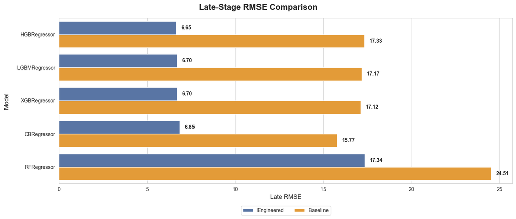

# Summary

Remaining Useful Life (RUL) prediction is an important task in predictive maintenance, aiming to estimate the operational time remaining before equipment failure. Accurate RUL estimation enables more efficient maintenance scheduling, reduces operational costs, and improves system reliability.

To capture temporal degradation behavior, the data was transformed into sequential intervals using a sliding sequence approach. Several preprocessing and feature engineering techniques were applied to represent changes in engine condition over time, which contributed to a significant error reduction of RUL estimation.

Multiple regression models were evaluated for the RUL prediction task, including Random Forest Regressor, XGBoost Regressor, LightGBM Regressor, CatBoost Regressor, and Histogram-based Gradient Boosting Regressor. Model performance was assessed using Root Mean Squared Error (RMSE) and Mean Absolute Error (MAE), as well as stage-wise evaluation across early, mid, and late engine life.

The results show that prediction performance strongly depends on the degradation stage. Early-stage and mid-stage predictions present higher error due to weak, unstable, and transient degradation signatures, while late-stage predictions achieve significantly better accuracy as degradation patterns become more detectable and persistent in the sensor data. Gradient boosting methods achieved the best overall performance.

Overall, the developed pipeline provides an effective machine learning framework for RUL estimation and highlights the challenges associated with early-stage prognostics in complex engineered systems.

# About The Study

This study investigates the prediction of jet engine Remaining Useful Life (RUL), using simulated time-series data from multiple sensors and machine learning techniques. To achieve this, widely used Python libraries for data analysis and machine learning are employed, including tools for data manipulation, visualization, and predictive modeling. The study follows a structured approach, beginning with data preprocessing, followed by exploratory data analysis (EDA) and feature engineering, and concluding with model training and results comparison.

# About The Dataset

The dataset consists of jet engine operational cycles and sensor measurements collected throughout a simulated degradation process provided by National Aeronautics and Space Administration (NASA).

Dataset link: https://data.nasa.gov/dataset/cmapss-jet-engine-simulated-data

```python
import pandas as pd
import numpy as np
#import time
#import threading
#import csv, sqlite3
#import statistics
import matplotlib.pyplot as plt
import matplotlib.colors as mcolors
from matplotlib.colors import LinearSegmentedColormap, TwoSlopeNorm, Normalize
import matplotlib.gridspec as gridspec
#import plotly.graph_objects as go
from plotly.subplots import make_subplots
import seaborn as sns
from scipy.signal import savgol_filter
#from datetime import date, timedelta
# from ibapi.client  import EClient
# from ibapi.wrapper import EWrapper
# from ibapi.contract import Contract
# from ibapi.ticktype import TickTypeEnum
from sklearn.preprocessing import StandardScaler, LabelEncoder
from sklearn.utils import compute_sample_weight
from sklearn.feature_selection import f_classif, mutual_info_regression
from sklearn.model_selection import train_test_split
from sklearn.linear_model import LogisticRegression, LinearRegression
from sklearn.metrics import confusion_matrix, precision_score, recall_score, f1_score, precision_recall_curve, roc_auc_score, roc_curve, average_precision_score, accuracy_score, matthews_corrcoef, log_loss, brier_score_loss, mean_squared_error, mean_absolute_error
from sklearn.calibration import calibration_curve
from sklearn.model_selection import RandomizedSearchCV, StratifiedKFold
from sklearn.svm import SVC, SVR
# from sklearn.tree import DecisionTreeClassifier
# from sklearn.neighbors import KNeighborsClassifier
from sklearn.ensemble import RandomForestClassifier, RandomForestRegressor
from sklearn.ensemble import HistGradientBoostingRegressor
from catboost import CatBoostClassifier, CatBoostRegressor
# from sklearn.neural_network import MLPClassifier
# from sklearn import metrics
from xgboost import XGBClassifier, XGBRegressor
from lightgbm import LGBMClassifier, LGBMRegressor
import shap
import warnings

warnings.filterwarnings("ignore")
pd.set_option('display.max_rows', None)
pd.set_option('display.max_columns', None)
pd.set_option('display.max_colwidth', None)
```

# Methodology

- Data Wrangling and Preprocessing
- Exploratory Data Analysis and Feature Evaluation
- Model Training
- Results Comparison
- Discussion
- Conclusion

# Data Wrangling and Preprocessing

The dataset consists of training, testing, and Remaining Useful Life (RUL) files. In this study, only the train_FD001 subset was used. This subset contains operational data from 100 jet engines operating under a single fault condition and a single operating condition.

Each engine was monitored over a varying number of operational cycles until failure. The dataset does not include column labels directly; therefore, variable names provided in the accompanying metadata file were assigned. The dataset structure is organized as follows:

- engine_id: unique identifier for each engine
- cycle: operational cycle number
- setting_1 to setting_3: operational setting variables
- sensor_1 to sensor_21: sensor measurements collected during engine operation

The target variable, Remaining Useful Life (RUL), was computed by subtracting the current cycle from the maximum cycle observed for each engine.

Summary statistics of the dataset variables are presented below.

```python
df = pd.read_csv("train_FD001.txt", sep=r"\s+", header=None)
columns = (
    ["engine_id", "cycle"] +
    [f"setting_{i}" for i in range(1, 4)] +
    [f"sensor_{i}" for i in range(1, 22)]
)
df.columns = columns
df.info(verbose=False)
df.describe()
```

```
<class 'pandas.core.frame.DataFrame'>
RangeIndex: 20631 entries, 0 to 20630
Columns: 26 entries, engine_id to sensor_21
dtypes: float64(22), int64(4)
memory usage: 4.1 MB
```

|  | engine_id | cycle | setting_1 | setting_2 | setting_3 | sensor_1 | sensor_2 | sensor_3 | sensor_4 | sensor_5 | sensor_6 | sensor_7 | sensor_8 | sensor_9 | sensor_10 | sensor_11 | sensor_12 | sensor_13 | sensor_14 | sensor_15 | sensor_16 | sensor_17 | sensor_18 | sensor_19 | sensor_20 | sensor_21 |
| --- | --- | --- | --- | --- | --- | --- | --- | --- | --- | --- | --- | --- | --- | --- | --- | --- | --- | --- | --- | --- | --- | --- | --- | --- | --- | --- |
| count | 20631.000000 | 20631.000000 | 20631.000000 | 20631.000000 | 20631.0 | 20631.00 | 20631.000000 | 20631.000000 | 20631.000000 | 2.063100e+04 | 20631.000000 | 20631.000000 | 20631.000000 | 20631.000000 | 20631.0 | 20631.000000 | 20631.000000 | 20631.000000 | 20631.000000 | 20631.000000 | 2.063100e+04 | 20631.000000 | 20631.0 | 20631.0 | 20631.000000 | 20631.000000 |
| mean | 51.506568 | 108.807862 | -0.000009 | 0.000002 | 100.0 | 518.67 | 642.680934 | 1590.523119 | 1408.933782 | 1.462000e+01 | 21.609803 | 553.367711 | 2388.096652 | 9065.242941 | 1.3 | 47.541168 | 521.413470 | 2388.096152 | 8143.752722 | 8.442146 | 3.000000e-02 | 393.210654 | 2388.0 | 100.0 | 38.816271 | 23.289705 |
| std | 29.227633 | 68.880990 | 0.002187 | 0.000293 | 0.0 | 0.00 | 0.500053 | 6.131150 | 9.000605 | 5.329200e-15 | 0.001389 | 0.885092 | 0.070985 | 22.082880 | 0.0 | 0.267087 | 0.737553 | 0.071919 | 19.076176 | 0.037505 | 3.469531e-18 | 1.548763 | 0.0 | 0.0 | 0.180746 | 0.108251 |
| min | 1.000000 | 1.000000 | -0.008700 | -0.000600 | 100.0 | 518.67 | 641.210000 | 1571.040000 | 1382.250000 | 1.462000e+01 | 21.600000 | 549.850000 | 2387.900000 | 9021.730000 | 1.3 | 46.850000 | 518.690000 | 2387.880000 | 8099.940000 | 8.324900 | 3.000000e-02 | 388.000000 | 2388.0 | 100.0 | 38.140000 | 22.894200 |
| 25% | 26.000000 | 52.000000 | -0.001500 | -0.000200 | 100.0 | 518.67 | 642.325000 | 1586.260000 | 1402.360000 | 1.462000e+01 | 21.610000 | 552.810000 | 2388.050000 | 9053.100000 | 1.3 | 47.350000 | 520.960000 | 2388.040000 | 8133.245000 | 8.414900 | 3.000000e-02 | 392.000000 | 2388.0 | 100.0 | 38.700000 | 23.221800 |
| 50% | 52.000000 | 104.000000 | 0.000000 | 0.000000 | 100.0 | 518.67 | 642.640000 | 1590.100000 | 1408.040000 | 1.462000e+01 | 21.610000 | 553.440000 | 2388.090000 | 9060.660000 | 1.3 | 47.510000 | 521.480000 | 2388.090000 | 8140.540000 | 8.438900 | 3.000000e-02 | 393.000000 | 2388.0 | 100.0 | 38.830000 | 23.297900 |
| 75% | 77.000000 | 156.000000 | 0.001500 | 0.000300 | 100.0 | 518.67 | 643.000000 | 1594.380000 | 1414.555000 | 1.462000e+01 | 21.610000 | 554.010000 | 2388.140000 | 9069.420000 | 1.3 | 47.700000 | 521.950000 | 2388.140000 | 8148.310000 | 8.465600 | 3.000000e-02 | 394.000000 | 2388.0 | 100.0 | 38.950000 | 23.366800 |
| max | 100.000000 | 362.000000 | 0.008700 | 0.000600 | 100.0 | 518.67 | 644.530000 | 1616.910000 | 1441.490000 | 1.462000e+01 | 21.610000 | 556.060000 | 2388.560000 | 9244.590000 | 1.3 | 48.530000 | 523.380000 | 2388.560000 | 8293.720000 | 8.584800 | 3.000000e-02 | 400.000000 | 2388.0 | 100.0 | 39.430000 | 23.618400 |

Missing values were inspected and no missing observations were found in the dataset. Based on the summary statistics, some features presented only a single unique value across all observations. Such features exhibit no variance and therefore provide no discriminative or predictive information for machine learning tasks, including clustering, regression, and anomaly detection. Consequently, these features were removed from the dataset.

To support Remaining Useful Life (RUL) estimation, the maximum operational cycle reached by each engine (max_cycle) was first computed by grouping the dataset by engine_id and extracting the maximum value of the cycle variable. This intermediate quantity was then used to derive the target variable, Remaining Useful Life (RUL), defined as the difference between max_cycle and the current cycle for each observation. After target construction, max_cycle was removed.

```python
nunique = df.nunique()
constant_cols = nunique[nunique == 1].index.tolist()
df = df.drop(columns=constant_cols)
max_cycles = df.groupby("engine_id")["cycle"].max()
df["max_cycle"] = df["engine_id"].map(max_cycles)
df["RUL"] = df["max_cycle"] - df["cycle"]
df = df.drop(columns=["max_cycle"])
print("Features removed:", constant_cols)
```

```
Features removed: ['setting_3', 'sensor_1', 'sensor_5', 'sensor_10', 'sensor_16', 'sensor_18', 'sensor_19']
```

# Exploratory Data Analysis and Feature Evaluation

Below is a chart of a selected sensor from four engines. Each engine exhibits different lifetime and signal amplitude. Several sensors show a common structural pattern: an initial phase of relatively stable oscillation within a narrow range, followed by a later phase where the signal begins to deviate from its baseline behavior, often showing increased variability or directional drift as the engine approaches failure.

This suggests a two-regime behavior in certain sensors: an early operational steady-state regime characterized by bounded oscillations, and a late-stage degradation regime where statistical properties of the signal shift away from baseline behavior. The transition point varies across engines and is associated with remaining useful life.

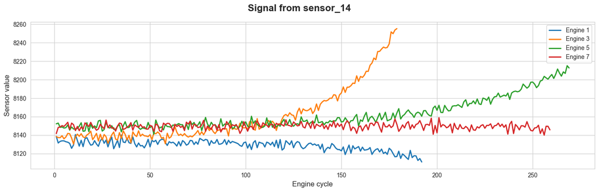

```python
def plot_engines_sensors_demonstration_samples(sensor_number):
    sns.set_style("whitegrid")
    engines = range(1, 9, 2)#[1, 5, 26, 56]
    sensor = f"sensor_{sensor_number}"
    fig, ax = plt.subplots(figsize=(14, 4.5))
    fig.suptitle( f"Signal from {sensor}", y=0.98, fontsize=16, fontweight="bold" )

    for engine_id in engines:
        engine = df[df["engine_id"] == engine_id]

        sns.lineplot(
            data=engine,
            x="cycle",
            y=sensor,
            ax=ax,
            linewidth=2,
            label=f"Engine {engine_id}"
        )

        ax.set_xlabel("Engine cycle", fontsize=12)
        ax.set_ylabel("Sensor value", fontsize=12)

    plt.legend()
    plt.tight_layout()
    plt.show()

plot_engines_sensors_demonstration_samples(14)
```

Sensor_6 exhibits a highly concentrated distribution, remaining nearly constant for most cycles and presenting only a few isolated one-cycle binary transitions. Such behavior is not aligned with the continuous degradation assumption underlying the majority of sensor features. This mismatch in signal structure may bias feature importance estimates and degrade model generalization, particularly for regression-based models.

In contrast, several other sensors exhibit a more consistent degradation structure, characterized by an initial operational stage in which the signal oscillates within a narrow range, followed by a degradation phase where the signal begins to drift away from its healthy operating region and progressively develops a clearer and steeper trend as the engine approaches failure.

Below is a plot grid illustrating a selection of sensor and operational setting signals from a representative engine, together with some statistical indicators. These visualizations demonstrate the progressive deviation from baseline operating conditions and the temporal degradation patterns captured throughout the engine lifecycle. The red envelopes represent a visualization aid defined by the mean and one standard deviation of the sensor signal. These envelopes were further modified by freezing their value from the most stable cycle identified in the early operational phase for each sensor. Although initially designed as a degradation thresholding mechanism to enhance linearity in subsequent feature transformations, this approach did not yield improvements in predictive performance. Nevertheless, the visualization is retained as it provides an intuitive interpretation of deviation from baseline operating conditions and supports understanding of the degradation process.

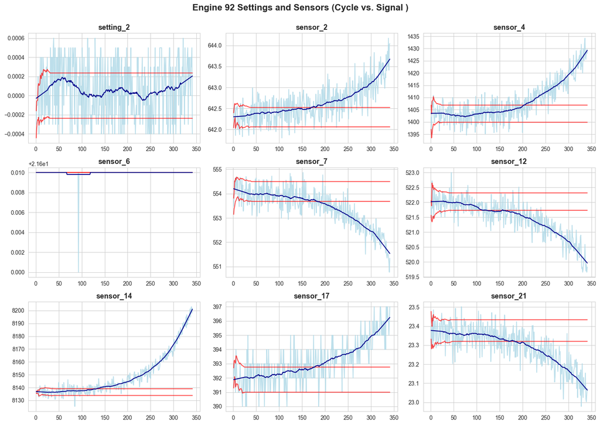

```python
def plot_engine_settings_and_sensors(engine_number):
    sns.set_style("whitegrid")
    engine = df[df["engine_id"] == engine_number].copy()
    features = [ c for c in df.columns if c not in ["engine_id", "cycle", "RUL", "setting_1", "sensor_3", "sensor_8", "sensor_9", "sensor_11", "sensor_13", "sensor_15", "sensor_20"] ]

    n_features = len(features)
    cols = 3
    rows = int(np.ceil(n_features / cols))

    fig, axes = plt.subplots( rows, cols, figsize=(15, rows * 3.5 ) )
    fig.suptitle(f"Engine {engine_number} Settings and Sensors (Cycle vs. Signal )", y=1.0, fontsize=16, fontweight="bold")
    axes = axes.flatten()

    for i, col in enumerate(features):
        expanding_mean = engine[col].expanding().mean()
        expanding_std = engine[col].expanding().std().bfill()
        min_std_index = expanding_std.iloc[20:79].idxmin()
        expanding_mean.loc[min_std_index:] = expanding_mean.loc[min_std_index]
        expanding_std.loc[min_std_index:] = expanding_std.loc[min_std_index]
        up_band = expanding_mean + expanding_std
        lo_band = expanding_mean - expanding_std
        savgol = savgol_filter( engine[col], window_length=51, polyorder=1, mode='interp' )

        # for k in range(20, len(savgol)):
        #     if savgol[k - 1] >= up_band.iloc[k - 1] and savgol[k] < savgol[k - 1]:
        #         savgol[k] = savgol[k - 1]
        #     if savgol[k - 1] <= lo_band.iloc[k - 1] and savgol[k] > savgol[k - 1]:
        #         savgol[k] = savgol[k - 1]

        axes[i].plot( engine["cycle"], engine[col], color='lightblue', label=col, alpha=0.8 )
        axes[i].plot( engine["cycle"], up_band, color='red', alpha=0.7 )
        axes[i].plot( engine["cycle"], lo_band, color='red', alpha=0.7 )
        axes[i].plot( engine["cycle"], savgol, color='darkblue', linestyle='-', label='Savgol' )
        axes[i].set_title(col, fontsize=13, fontweight="bold")
        axes[i].set_xlabel("")

    for j in range(n_features, len(axes)):
        fig.delaxes(axes[j])

    n_cols = 3
    for col in range(n_cols):
        col_axes = axes[col::n_cols]
        col_axes = [ax for ax in col_axes if ax in fig.axes]
        if col_axes:
            last_ax = col_axes[-1]
            last_ax.tick_params(labelbottom=True)

    plt.tight_layout()
    plt.show()

plot_engine_settings_and_sensors(92)
```

Additional features were engineered to capture both linear and non-linear degradation behavior, providing the models with more informative representations than the original sensor measurements alone and improving predictive performance. These engineered features were applied to all sensors used at this stage and consisted of a smoothed z-score, a band breakout binary signal, a simple moving average, and a Savitzky–Golay filter.

After evaluating multiple configurations and combinations of the engineered features, the best performance was achieved using the Savitzky–Golay filter alone, particularly in terms of late-stage accuracy. This indicates that preserving the underlying degradation trajectory while reducing high-frequency noise was more effective than more complex feature engineering approaches tested in this study.

Therefore, a Savitzky–Golay filter with a 51-period window and polynomial order of 1 was introduced to provide a smoother representation of the underlying sensor dynamics while maintaining lower lag compared to a simple moving average and alternative distance-based smoothing approaches.

Feature correlation analysis was performed to identify highly correlated pairs of independent variables, enabling the removal of redundant features and improving model robustness.

A correlation threshold of 0.95 was adopted, such that when two independent variables exhibited an absolute correlation coefficient equal to or greater than this value, the feature with the lower mutual information score relative to the target variable was removed. This approach reduces feature redundancy while preserving the variables with the highest predictive relevance, mitigating multicollinearity effects and decreasing the risk of overfitting.

Sensors 9 and 14 were identified as a highly correlated pair during the correlation analysis. Sensor 9 exhibited the lower mutual information score with respect to the target variable and was therefore excluded from the feature set.

```python
def feature_correlation_check(data, threshold=0.95):
    X = data.drop("RUL", axis=1)
    y = data["RUL"]
    scaler = StandardScaler()
    X = pd.DataFrame( scaler.fit_transform(X), columns=X.columns, index=X.index )
    corr_matrix_before = X.corr().abs()
    upper = corr_matrix_before.where( np.triu(np.ones(corr_matrix_before.shape), k=1).astype(bool) )
    pairs = upper.stack().reset_index()
    pairs.columns = ["feature_1", "feature_2", "correlation"]
    redundant_pairs = pairs[pairs["correlation"] > threshold].sort_values("correlation", ascending=False)

    mi = mutual_info_regression(X, y)
    mi_lookup = pd.Series(mi, index=X.columns).to_dict()
    to_remove = set()

    for _, row in redundant_pairs.iterrows():
        f1, f2 = row["feature_1"], row["feature_2"]
        mi1 = mi_lookup.get(f1, 0)
        mi2 = mi_lookup.get(f2, 0)
        if mi1 < mi2:
            to_remove.add(f1)
        else:
            to_remove.add(f2)

    corr_matrix_after = X.drop(list(to_remove), axis=1).corr().abs()
    mi = pd.DataFrame({"Feature": X.columns, "MI": mi}).sort_values("MI", ascending=False).reset_index(drop=True).T

    return redundant_pairs, to_remove, corr_matrix_before, corr_matrix_after, mi

redundant_pairs, to_drop, corr_matrix_before, corr_matrix_after, mi = feature_correlation_check(df)
df = df.drop(to_drop, axis=1)
redundant_pairs
```

|  | feature_1 | feature_2 | correlation |
| --- | --- | --- | --- |
| 138 | sensor_9 | sensor_14 | 0.963157 |

In the next step, new engineered features will be implemented. These features are identified by appending a suffix to the corresponding original feature names. Following the new features implementation, the original variables were removed from the dataset to avoid redundancy and ensure that only the engineered representations are used in subsequent modeling.

The following bar plot presents the correlation between the engineered features and the target variable (RUL). Most features show a strong degree of linear association with the target variable, indicating that the engineered feature space effectively captures degradation-related information.

```python
df = df.drop(columns=["setting_1", "setting_2", "sensor_6"])
features = [feature for feature in df.columns if "sensor" in feature]
grouped = df.groupby("engine_id")
for col in features:
    for engine_id, engine in grouped:
        savgol = savgol_filter( engine[col], window_length=51, polyorder=1, mode='interp' )
        df.loc[engine.index, f"{col}_savgol"] = savgol

    df[f"{col}_savgol"] = grouped[f"{col}_savgol"].bfill()

df = df.drop(columns=features)
```

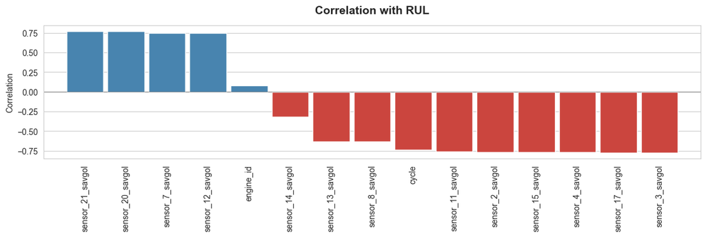

```python
def plot_feature_correlation(data):
    corr = data.corr()["RUL"].drop("RUL").sort_values(ascending=False)
    sns.set_style("whitegrid")

    full_cmap = LinearSegmentedColormap.from_list(
        "red_white_blue",
        ["#b2182b", "#ffffff", "#08306b"]
    )
    def get_colors(values):
        vmin, vmax = values.min(), values.max()

        if vmin < 0 and vmax > 0:
            norm = TwoSlopeNorm(vmin=vmin, vcenter=0, vmax=vmax)
            cmap = full_cmap
        elif vmin >= 0:
            norm = Normalize(vmin=vmin, vmax=vmax)
            cmap = LinearSegmentedColormap.from_list(
                "white_blue",
                ["#DEEBF7", "#08306B"]
            )
        else:
            norm = Normalize(vmin=vmin, vmax=vmax)
            cmap = LinearSegmentedColormap.from_list(
                "red_white",
                ["#B2182B", "#DEEBF7"]
            )
        return list(cmap(norm(values)))

    values = corr.values
    colors = get_colors(values)

    fig, ax = plt.subplots(figsize=(13, 3.2))

    sns.barplot(
        x=corr.index,
        y=corr.values,
        hue=corr.index,
        palette=colors,
        legend=False,
        ax=ax
    )

    ax.tick_params(axis='x', rotation=90)
    ax.set_title("Correlation with RUL", fontsize=14, fontweight="bold", pad=14)
    ax.set_xlabel(None)
    ax.set_ylabel("Correlation")
    ax.axhline(y=0, color="black", linewidth=0.3)
    ax.set_xlim(-1, max(corr.index.nunique(), 10))
    fig.canvas.draw()
    renderer = fig.canvas.get_renderer()
    max_height_px = max(
        label.get_window_extent(renderer=renderer).height
        for label in ax.get_xticklabels()
    )
    dpi = fig.dpi
    extra_height_inch = max_height_px / dpi
    fig.set_size_inches(12, 3 + extra_height_inch)

    plt.tight_layout()
    plt.show()

plot_feature_correlation(df)
```

# Model Training

In the next step, the dataset is split into training and testing sets at the engine level to enable proper training of the regression models and unbiased evaluation of their performance. The dataset consists of 100 engines. The training set includes 80 engines, while the test set includes 20 engines.

The models used include Random Forest Regressor, XGBoost Regressor, LightGBM Regressor, CatBoost Regressor, and Histogram-based Gradient Boosting Regressor. The variables cycle and engine_id are excluded from the set of independent variables to prevent data leakage and ensure that only predictive sensor-based features are used.

```python
features = [feature for feature in df.columns if not any(keyword in feature for keyword in ["engine_id", "cycle", "RUL"])]

train_engines = df["engine_id"].unique()[:80]
test_engines = df["engine_id"].unique()[80:]

def create_sequences(df, features, seq_len=30):
    X = []
    y = []

    for _, engine in df.groupby("engine_id"):
        data = engine[features].values
        rul = engine["RUL"].values

        for i in range(len(engine) - seq_len):
            X.append(data[i:i+seq_len])
            y.append(rul[i+seq_len-1])

    return np.array(X), np.array(y)

def life_stage_rmse(y_true, y_pred, test_df, seq_len=30):
    early, mid, late = [], [], []
    start = 0

    for _, engine in test_df.groupby("engine_id"):
        n = len(engine) - seq_len
        if n <= 0:
            continue
        true = y_true[start:start+n]
        pred = y_pred[start:start+n]
        start += n
        cut1 = int(n * 0.3)
        cut2 = int(n * 0.7)
        early.append(mean_squared_error(true[:cut1], pred[:cut1]))
        mid.append(mean_squared_error(true[cut1:cut2], pred[cut1:cut2]))
        late.append(mean_squared_error(true[cut2:], pred[cut2:]))

    return (
        np.sqrt(np.mean(early)),
        np.sqrt(np.mean(mid)),
        np.sqrt(np.mean(late))
    )

regression_models = {
    "RFRegressor": RandomForestRegressor( n_estimators=300, max_depth=3, random_state=42),
    "XGBRegressor": XGBRegressor( n_estimators=300, max_depth=3, learning_rate=0.03, subsample=0.7, colsample_bytree=0.7, random_state=42 ),
    "LGBMRegressor" : LGBMRegressor(n_estimators=300, max_depth=3, learning_rate=0.03, subsample=0.7, colsample_bytree=0.7, random_state=42, verbose=0 ),
    "CBRegressor": CatBoostRegressor( iterations=300, learning_rate=0.03, depth=8, loss_function="RMSE", random_seed=42, verbose=0 ),
    "HGBRegressor": HistGradientBoostingRegressor( max_iter=300, max_depth=3, learning_rate=0.03, random_state=42, verbose=0 )
}

models = dict()

for name, model in regression_models.items():
    train_df = df[df["engine_id"].isin(train_engines)].copy()
    test_df = df[df["engine_id"].isin(test_engines)].copy()
    if name not in ["RFRegressor", "XGBRegressor", "LGBMRegressor", "CBRegressor", "HGBRegressor"]:
        scaler = StandardScaler()
        train_df[features] = scaler.fit_transform(train_df[features])
        test_df[features] = scaler.transform(test_df[features])
    X_train, Y_train = create_sequences( train_df, features, seq_len=30 )
    X_test, Y_test = create_sequences( test_df, features, seq_len=30 )
    X_train_flat = X_train.reshape(X_train.shape[0], -1)
    X_test_flat = X_test.reshape(X_test.shape[0], -1)

    model.fit(X_train_flat, Y_train)
    y_pred = model.predict(X_test_flat)
    rmse = np.sqrt(mean_squared_error(Y_test, y_pred))
    mae = mean_absolute_error(Y_test, y_pred)
    early_rmse, mid_rmse, late_rmse = life_stage_rmse(Y_test, y_pred, test_df, seq_len=30)

    metrics = pd.DataFrame([{"RMSE": rmse, "Early_RMSE": early_rmse, "Mid_RMSE": mid_rmse, "Late_RMSE": late_rmse, "MAE": mae}])

    models.update( { f"{name}": {"metrics": metrics, "best_model": model, "y_pred": y_pred} } )
```

# Results Comparison

The following table presents the prediction errors in Remaining Useful Life (RUL) estimation, obtained by evaluating all trained models in two separate experiments: one using the baseline feature set and one using the engineered feature set. The models are ranked according to Late_RMSE in ascending order, as late-stage prediction accuracy is the most operationally relevant criterion for RUL estimation.

```python
def model_comparison():
    df_all = []
    for name, model in models.items():
        df_models = model["metrics"].copy()
        df_models["Model"] = name
        cols = ["RMSE", "Early_RMSE", "Mid_RMSE", "Late_RMSE", "MAE"]
        df_models = df_models[["Model"] + [c for c in cols if c in df_models.columns]]
        df_all.append(df_models)
    df_all = pd.concat(df_all).reset_index(drop=True)

    models_best_performance = df_all.sort_values(["Late_RMSE", "Mid_RMSE", "Early_RMSE"]).reset_index(drop=True)

    return models_best_performance

df_comparison = model_comparison()
# df_comparison.to_csv("performance_with_engineered_features.csv", index=False)
# df_comparison.to_csv("performance_with_baseline_features.csv", index=False)
```

```python
df_engineered = pd.read_csv("performance_with_engineered_features.csv")
df_baseline = pd.read_csv("performance_with_baseline_features.csv")
df_engineered.loc[:,"Features"] = "Engineered"
df_baseline.loc[:,"Features"] = "Baseline"
df_compare = pd.concat([df_engineered, df_baseline], ignore_index=True)
df_compare
```

|  | Model | RMSE | Early_RMSE | Mid_RMSE | Late_RMSE | MAE | Features |
| --- | --- | --- | --- | --- | --- | --- | --- |
| 0 | HGBRegressor | 38.987999 | 53.315100 | 28.803768 | 6.647421 | 25.078747 | Engineered |
| 1 | LGBMRegressor | 39.370077 | 54.081946 | 28.463356 | 6.697453 | 25.352884 | Engineered |
| 2 | XGBRegressor | 39.085437 | 53.817904 | 27.811844 | 6.700502 | 25.120392 | Engineered |
| 3 | CBRegressor | 40.266947 | 56.103616 | 27.571152 | 6.853846 | 25.941789 | Engineered |
| 4 | RFRegressor | 48.209035 | 63.467405 | 38.536840 | 17.344461 | 33.082135 | Engineered |
| 5 | CBRegressor | 43.310215 | 59.273050 | 30.774656 | 15.768038 | 29.888413 | Baseline |
| 6 | XGBRegressor | 43.782429 | 59.692649 | 31.629974 | 17.116106 | 30.422464 | Baseline |
| 7 | LGBMRegressor | 44.080566 | 60.050631 | 31.930167 | 17.174256 | 30.669344 | Baseline |
| 8 | HGBRegressor | 44.209609 | 60.194413 | 32.168977 | 17.325539 | 30.882475 | Baseline |
| 9 | RFRegressor | 49.265040 | 66.072834 | 37.018623 | 24.513656 | 35.369121 | Baseline |

Improvements in mid-stage prediction are also observed, albeit to a lesser extent, while early-stage prediction remains challenging due to the limited observability of degradation patterns in the initial operational regime. Overall, the results indicate that the engineered feature space enhances the model’s ability to represent degradation progression, especially as the system approaches failure.

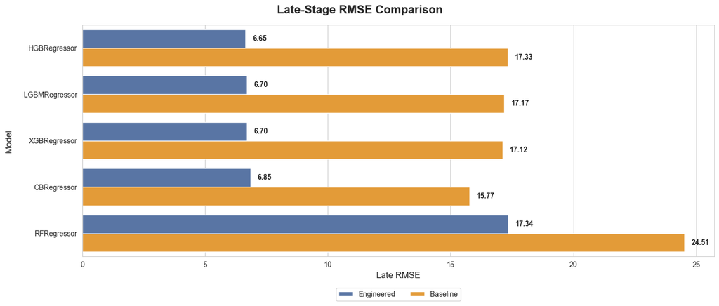

```python
def plot_model_comparison():

    fig, ax = plt.subplots(figsize=(14, 6))
    fig.suptitle( "Late-Stage RMSE Comparison", y=0.98, fontsize=16, fontweight="bold" )

    df_melt = df_compare.melt(
        id_vars=["Model", "Features"],
        value_vars=["Late_RMSE"]
    )

    sns.barplot(
        data=df_melt,
        x="value",
        y="Model",
        hue="Features",
        ax=ax,
        palette=["#4C72B0", "#FF9F1C"] # "Reds", "Oranges", "Greens", "Purples", "Greys", "Blues", "deep", "muted", "dark", "colorblind",
    )
    for container in ax.containers:
        ax.bar_label(
            container,
            fmt="%.2f",
            padding=10,
            fontsize=10,
            fontweight="bold"
        )
    ax.set_ylabel("Model", fontsize=12, labelpad=15)
    ax.set_xlabel("Late RMSE", fontsize=12)
    #ax.tick_params(axis='x', rotation=0, pad=10)
    ax.legend(loc="upper center", bbox_to_anchor=(0.5, -0.12), ncol=df_melt["Features"].nunique())

    plt.tight_layout()
    plt.show()

plot_model_comparison()
```

# Discussion

A key finding of this work is the strong effectiveness of Savitzky–Golay (Savgol) filtering as a primary signal transformation. Using a relatively large window size (51 cycles), the Savgol transformation was able to significantly reduce high-frequency noise while preserving the underlying degradation structure. This resulted in more stable and informative representations of sensor trajectories, particularly in the late degradation phase, consistently producing superior late-stage RMSE performance. This suggests that, for this dataset, degradation dynamics are better captured through smooth trajectory estimation than through highly parameterized statistical transformations.

The analysis of Sensor 6 highlights that not all sensor signals contain meaningful degradation information, as highly concentrated and nearly constant signals may offer limited predictive power for RUL estimation. As a result, its contribution to regression models is limited and potentially detrimental, as its highly concentrated binary behavior is not aligned with the dominant continuous degradation dynamics observed in the remaining sensors. This justified its exclusion from the final feature set.

Highly correlated features were identified and removed to reduce redundancy and mitigate multicollinearity and improve robustness. In cases of highly correlated pairs, the feature exhibiting lower mutual information with respect to the target variable (RUL) was removed.

# Conclusion

Overall, this study focused on remaining useful life (RUL) prediction for jet engines under complex degradation dynamics in the CMAPSS FD001 dataset. Feature engineering approaches were evaluated as part of the modelling pipeline to assess their influence on predictive performance. The results demonstrate that the most significant performance gains are achieved not through model complexity, but through appropriate transformation of degradation signals provided by the sensors.

Among the tested approaches, Savitzky–Golay filtering emerged as the most effective transformation, providing a robust balance between noise reduction and preservation of degradation structure.

The proposed pipeline demonstrates that carefully designed signal smoothing can substantially reduce predictive error in the final stage, which is the most operationally relevant phase for maintenance decision-making.